# Concurrent Food vs. Social Choice

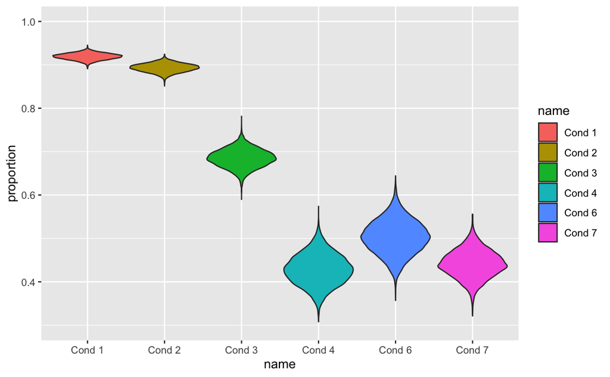

```r
plotdata <- data.frame(
  name = c( rep("Cond 1",8000), rep("Cond 2",8000), rep("Cond 3",8000), rep("Cond 4",8000), rep("Cond 6",8000), rep("Cond 7",8000) ),
  proportion = c( sample_parameter[[2]]$prob[,1], sample_parameter[[2]]$prob[,2], sample_parameter[[2]]$prob[,3], sample_parameter[[2]]$prob[,4], sample_parameter[[2]]$prob[,5], sample_parameter[[2]]$prob[,6] )
)
p <- ggplot(plotdata, aes(x=name, y=proportion, fill=name)) +
  geom_violin(scale="width") +
  ylim(0.3, 1)
print(p)
```

**Rat 8**

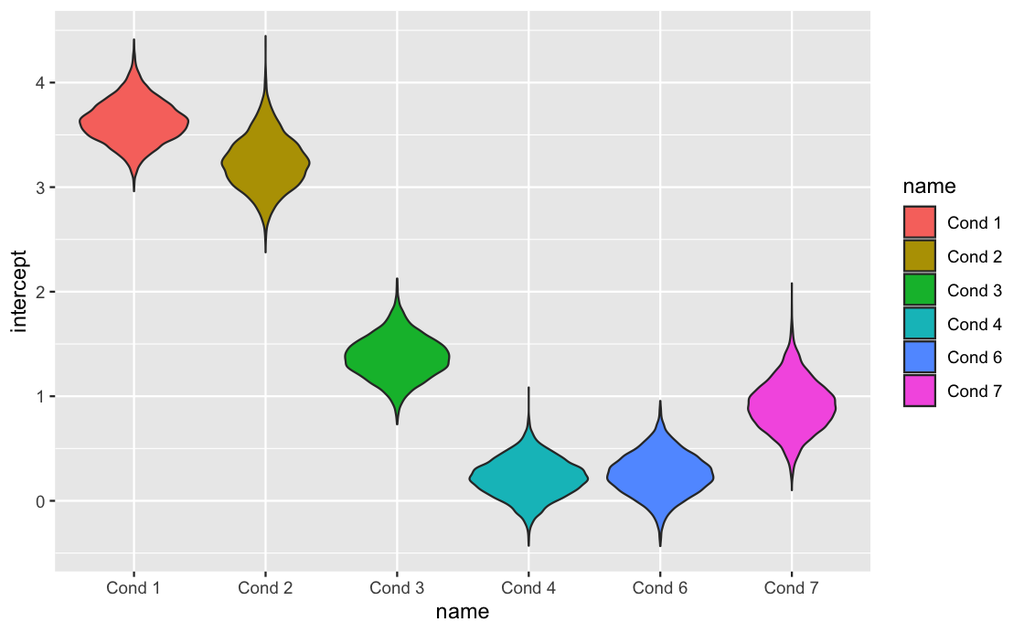

```r
plotdata <- data.frame(
  name = c( rep("Cond 1",8000), rep("Cond 2",8000), rep("Cond 3",8000), rep("Cond 4",8000), rep("Cond 6",8000), rep("Cond 7",8000) ),
  intercept = c( sample_parameter[[3]]$intercept[,1], sample_parameter[[3]]$intercept[,2], sample_parameter[[3]]$intercept[,3], sample_parameter[[3]]$intercept[,4], sample_parameter[[3]]$intercept[,5], sample_parameter[[3]]$intercept[,6] )
)
p <- ggplot(plotdata, aes(x=name, y=intercept, fill=name)) +
  geom_violin()
print(p)
```

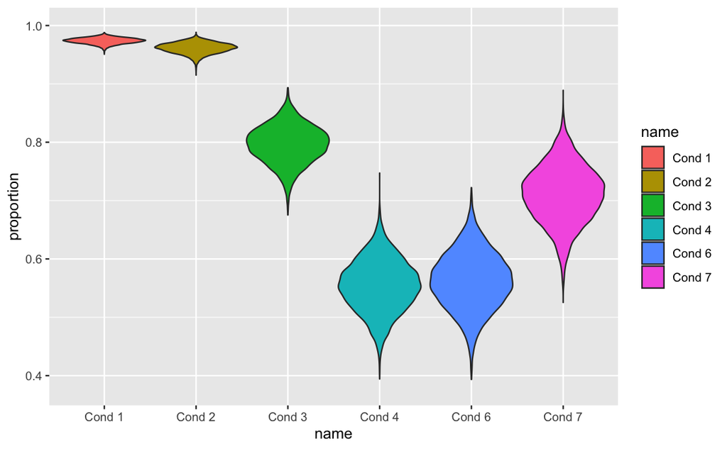

```r
plotdata <- data.frame(
  name = c( rep("Cond 1",8000), rep("Cond 2",8000), rep("Cond 3",8000), rep("Cond 4",8000), rep("Cond 6",8000), rep("Cond 7",8000) ),
  proportion = c( sample_parameter[[3]]$prob[,1], sample_parameter[[3]]$prob[,2], sample_parameter[[3]]$prob[,3], sample_parameter[[3]]$prob[,4], sample_parameter[[3]]$prob[,5], sample_parameter[[3]]$prob[,6] )
)
p <- ggplot(plotdata, aes(x=name, y=proportion, fill=name)) +
  geom_violin(scale="width") +
  ylim(0.38, 1)
print(p)
```

**Stan Analysis of Food Intake By Type**

For the most part, the logic of this block of code parallels that above. There is, however, a ltitle extra caution needed in manipulating the resulting parameters because the intercept abd self parameters in the stan model are more or less guaranteed to covary. As such, in order to talk about specific cases, it’s important to always example intercept as one case and intercept+self as the other case. Self as a parameter alone is going to be counterintuitive to interpret.

```r
model2 <- stan_model(file="intake_model.stan")

intake_output <- list()
sample_parameter_2 <- list()
nsample <- 2000
for (s in unique(Behav$Subject)) {
  mdata_1 <- (Behav$Subject == s)
  mdata_2 <- list(S = sum(mdata_1), C = length(unique(Behav$Condition[mdata_1])), condID = Behav$Condition[mdata_1], P = Behav$Food[mdata_1] * Behav$FoodAmmt[mdata_1], Shr=Behav$Sharing[mdata_1], Lft = Behav$PelletsLeft[mdata_1])
  mdata_2$Shr[mdata_2$Shr<0] <- 0
  mdata_2$Lft[mdata_2$Lft<0] <- 0
  mdata_2$NP <- mdata_2$Shr + mdata_2$Lft
  intake_output[s] <- list(sampling(model2, data = mdata_2, iter = nsample * 2, warmup = nsample, chains = 4, cores = 1, control = list(adapt_delta = 0.99, max_treedepth = 15)))
  sample_parameter_2[s] <- list(extract.samples(intake_output[[s]]))
  sample_parameter_2[[s]]$sum <- sample_parameter_2[[s]]$intercept + sample_parameter_2[[s]]$self
  sample_parameter_2[[s]]$pellets_left <- exp(sample_parameter_2[[s]]$intercept)
  sample_parameter_2[[s]]$pellets_produce <- exp(sample_parameter_2[[s]]$sum)
}
```

As noted in the model, NP is the sum of shared and ‘left behind’ pellets. Since these two categories of event are non-overlapping across conditions, we don’t run any risk in pooling them as a global event and then teasing the implications apart when we label the results.

As before, the parameters are averaged after-the-fact across subjects, rather than being part of a multi-level model. This approach is *not* an optimal use of the available data, but it should in principle be unbiased so long as subjects were independent samples. It’s also much easier to understand the model as it applies to single subjects.

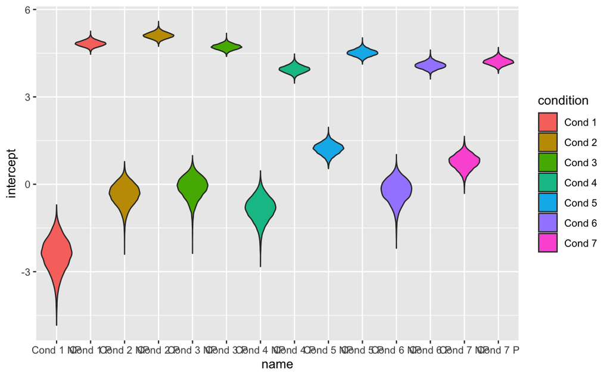

```r
sample_parameter_2[s+1] <- list(extract.samples(intake_output[[s]]))
sample_parameter_2[[s+1]]$intercept <- matrix(0, nrow(sample_parameter_2[[1]]$intercept), ncol(sample_parameter_2[[1]]$intercept))
sample_parameter_2[[s+1]]$self <- matrix(0, nrow(sample_parameter_2[[1]]$self), ncol(sample_parameter_2[[1]]$self))
sample_parameter_2[[s+1]]$sum <- matrix(0, nrow(sample_parameter_2[[1]]$sum), ncol(sample_parameter_2[[1]]$sum))

for (k in 1:s) {
  sample_parameter_2[[s+1]]$intercept <- sample_parameter_2[[s+1]]$intercept + sample_parameter_2[[k]]$intercept/s
  sample_parameter_2[[s+1]]$self <- sample_parameter_2[[s+1]]$self + sample_parameter_2[[k]]$self/s
  sample_parameter_2[[s+1]]$sum <- sample_parameter_2[[s+1]]$sum + sample_parameter_2[[k]]$sum/s
}
sample_parameter_2[[s+1]]$pellets_left <- exp(sample_parameter_2[[s+1]]$intercept)
sample_parameter_2[[s+1]]$pellets_produce <- exp(sample_parameter_2[[s+1]]$sum)

plotdata <- data.frame(
  name = c( rep("Cond 1 NP",8000), rep("Cond 1 P",8000), rep("Cond 2 NP",8000), rep("Cond 2 P",8000), rep("Cond 3 NP",8000), rep("Cond 3 P",8000), rep("Cond 4 NP",8000), rep("Cond 4 P",8000), rep("Cond 5 NP",8000), rep("Cond 5 P",8000), rep("Cond 6 NP",8000), rep("Cond 6 P",8000), rep("Cond 7 NP",8000), rep("Cond 7 P",8000) ),
  intercept = c( sample_parameter_2[[s+1]]$intercept[,1], sample_parameter_2[[s+1]]$sum[,1], sample_parameter_2[[s+1]]$intercept[,2], sample_parameter_2[[s+1]]$sum[,2], sample_parameter_2[[s+1]]$intercept[,3], sample_parameter_2[[s+1]]$sum[,3], sample_parameter_2[[s+1]]$intercept[,4], sample_parameter_2[[s+1]]$sum[,4], sample_parameter_2[[s+1]]$intercept[,5], sample_parameter_2[[s+1]]$sum[,5], sample_parameter_2[[s+1]]$intercept[,6], sample_parameter_2[[s+1]]$sum[,6], sample_parameter_2[[s+1]]$intercept[,7], sample_parameter_2[[s+1]]$sum[,7] ),
  condition = c( rep("Cond 1",16000), rep("Cond 2",16000), rep("Cond 3",16000), rep("Cond 4",16000), rep("Cond 5",16000), rep("Cond 6",16000), rep("Cond 7",16000) )
)
p <- ggplot(plotdata, aes(x=name, y=intercept, fill=condition)) +
  geom_violin(scale="width")
print(p)
```

[figure not shown]

```r
plotdata <- data.frame(
  name = c( rep("Cond 1 NP",8000), rep("Cond 1 P",8000), rep("Cond 2 NP",8000), rep("Cond 2 P",8000), rep("Cond 3 NP",8000), rep("Cond 3 P",8000), rep("Cond 4 NP",8000), rep("Cond 4 P",8000), rep("Cond 5 NP",8000), rep("Cond 5 P",8000), rep("Cond 6 NP",8000), rep("Cond 6 P",8000), rep("Cond 7 NP",8000), rep("Cond 7 P",8000) ),
  pellets = c( sample_parameter_2[[s+1]]$pellets_left[,1], sample_parameter_2[[s+1]]$pellets_taken[,1], sample_parameter_2[[s+1]]$pellets_left[,2], sample_parameter_2[[s+1]]$pellets_taken[,2], sample_parameter_2[[s+1]]$pellets_left[,3], sample_parameter_2[[s+1]]$pellets_taken[,3], sample_parameter_2[[s+1]]$pellets_left[,4], sample_parameter_2[[s+1]]$pellets_taken[,4], sample_parameter_2[[s+1]]$pellets_left[,5], sample_parameter_2[[s+1]]$pellets_taken[,5], sample_parameter_2[[s+1]]$pellets_left[,6], sample_parameter_2[[s+1]]$pellets_taken[,6], sample_parameter_2[[s+1]]$pellets_left[,7], sample_parameter_2[[s+1]]$pellets_taken[,7] ),
  condition = c( rep("Cond 1",16000), rep("Cond 2",16000), rep("Cond 3",16000), rep("Cond 4",16000), rep("Cond 5",16000), rep("Cond 6",16000), rep("Cond 7",16000) )
)
p <- ggplot(plotdata, aes(x=name, y=pellets, fill=condition)) +
  geom_violin(scale="width")
print(p)
```